# Exercise 2 Ada Xu & Tianyu Xu

2026-10-17

```r
library(tidyverse)
library(socviz)
library(ggplot2)
library(gapminder)
library(ggrepel)
library(scales)
```

## Healy (2026) Chapter 4

1. Revisit the gapminder plots at the beginning of the chapter and experiment with different ways to facet the data. Try plotting population and per capita GDP while faceting on year, or even on country. In the latter case you will get a lot of panels, and plotting them straight to the screen may take a long time. Instead, assign the plot to an object and save it as a PDF file to your figures/ folder. Experiment with the height and width of the figure.

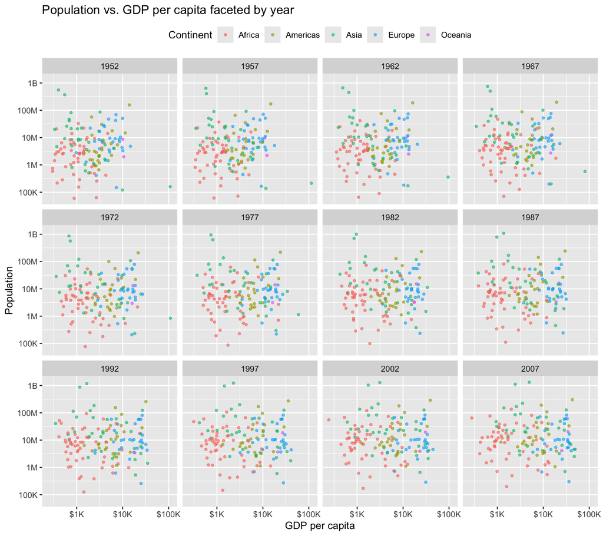

```r
# faceting on year
ggplot(data = gapminder, aes(x = gdpPercap, y = pop, color = continent)) +
  geom_point(alpha = 0.6, size = 1) +
  scale_x_log10(labels = label_dollar(scale_cut = cut_short_scale())) +
  scale_y_log10(labels = label_number(scale_cut = cut_short_scale())) +
  facet_wrap(~ year) +
  labs(x = "GDP per capita", y = "Population",
       color = "Continent",
       title = "Population vs. GDP per capita faceted by year") +
  theme(legend.position = "top")
```

```r
#faceting on country: with `facet_wrap(~ country)` we would get 142 tiny panels, but they are too small to read. So I choose a sample of the dataset about 25 countries in the Americas.
facet_on_country <-
  gapminder |>
  filter(continent == "Americas") |>
  ggplot(aes(x = gdpPercap, y = pop)) +
  geom_path() +
  geom_point(aes(color = year), size = 1) +
  scale_x_log10(labels = label_dollar(scale_cut = cut_short_scale())) +
  scale_y_log10(labels = label_number(scale_cut = cut_short_scale())) +
  scale_color_viridis_c() +
  facet_wrap(~ reorder(country, -pop), scales = "free_y", ncol = 5) +
  labs(x = "GDP per capita", y = "Population",
       color = "Year",
       title = "Faceting on country in the Americas, 1952-2007") +
  theme(strip.text = element_text(size = 8))
ggsave(filename = "my_figure.pdf",plot = facet_on_country )
```

2. Investigate the difference between a formula written as facet_grid(sex ~ race) versus one written as facet_grid(~ sex + race).

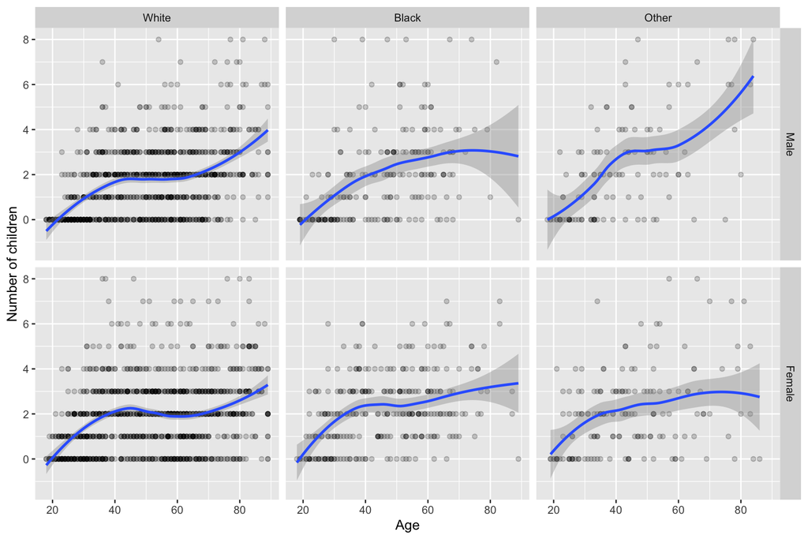

```r
#`sex ~ race` puts sex on the rows and race on the columns. This one seems leaner in visualization.
p <- ggplot(gss_sm, aes(x = age, y = childs)) +
  geom_point(alpha = 0.2) +
  geom_smooth(method = "loess") +
  labs(x = "Age", y = "Number of children")
p + facet_grid(sex ~ race)
```

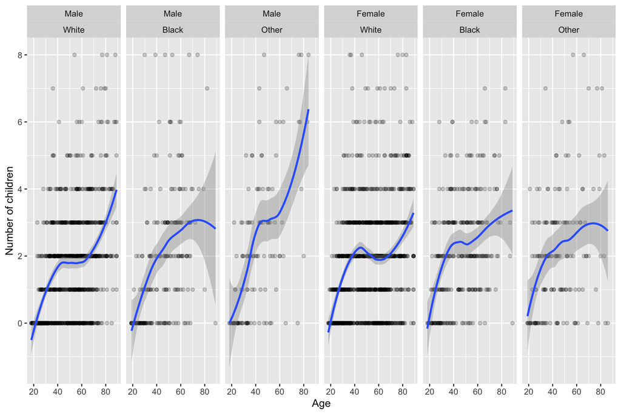

```r
#`~ sex + race` lays all the combinations in one row of 6 panels, labelled with both variables.
p <- ggplot(gss_sm, aes(x = age, y = childs)) +
  geom_point(alpha = 0.2) +
  geom_smooth(method = "loess") +
  labs(x = "Age", y = "Number of children")
p + facet_grid(~ sex + race)
```

3. Experiment to see what happens when you use facet_wrap() with more complex formulas like facet_wrap(~ sex + race) instead of facet_grid. Like facet_grid(), the facet_wrap() function can facet on two or more variables at once. But it will do it by laying the results out in a wrapped one-dimensional table instead of a fully cross-classified grid.

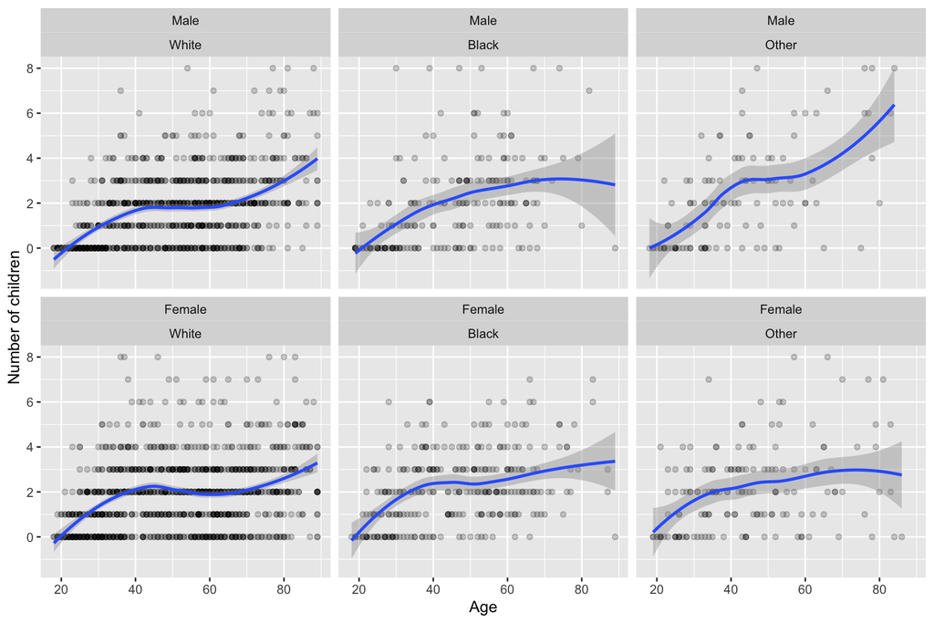

```r
p + facet_wrap(~ sex + race)
```

The graph looks similar to facet_grid(), so I can’t really tell the difference. I guess the difference might be the rows and columns of the layout have no meaning in facet_wrap().

4. Frequency polygons are closely related to histograms. Instead of displaying the count of observations using bars, they display it with a series of connected lines instead. You can try the various geom_histogram() calls in this chapter using geom_freqpoly() instead.

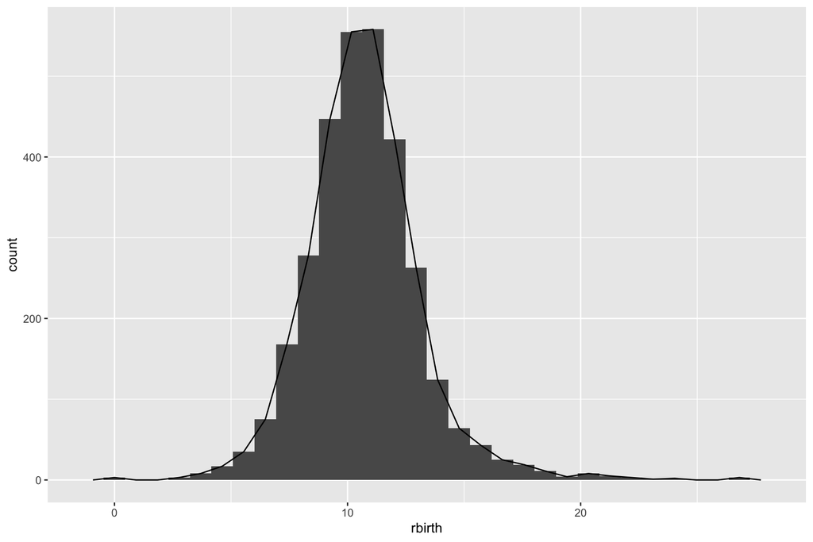

```r
p <- ggplot(data = county_comp, mapping = aes(x = rbirth))
p + geom_histogram() +
  geom_freqpoly()
```

5. A histogram bins observations for one variable and shows a bars with the count in each bin. We can do this for two variables at once, too. The geom_bin_2d() function takes two mappings, x and y. It divides your plot into a grid and colors the bins by the count of observations in them. Try using it on the gapminder data to plot life expectancy versus per capita GDP. Relatedly, geom_hex() does much the same thing but divides the xy plane into hexagons. (Hexagons are a popular choice here because there is no regular polygon with more sides that can still tessellate a plane, i.e. be arranged in a regular grid without any gaps.)

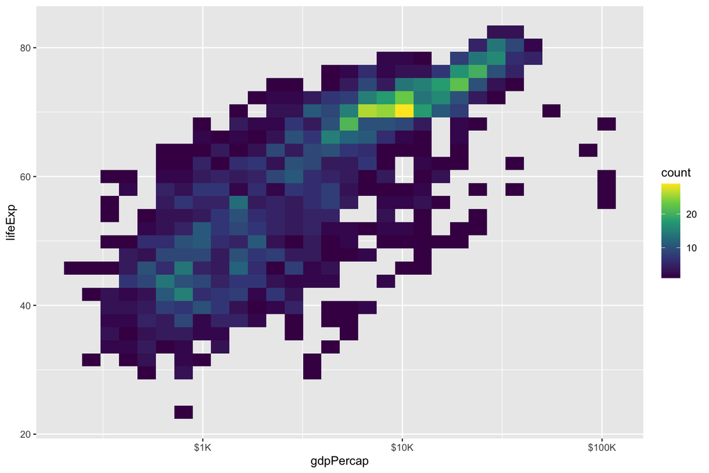

```r
g <- ggplot(gapminder, aes(x = gdpPercap, y = lifeExp))
g + scale_x_log10(labels = label_dollar(scale_cut = cut_short_scale())) +
  geom_bin_2d(bin=10) +
  scale_fill_viridis_c()
```

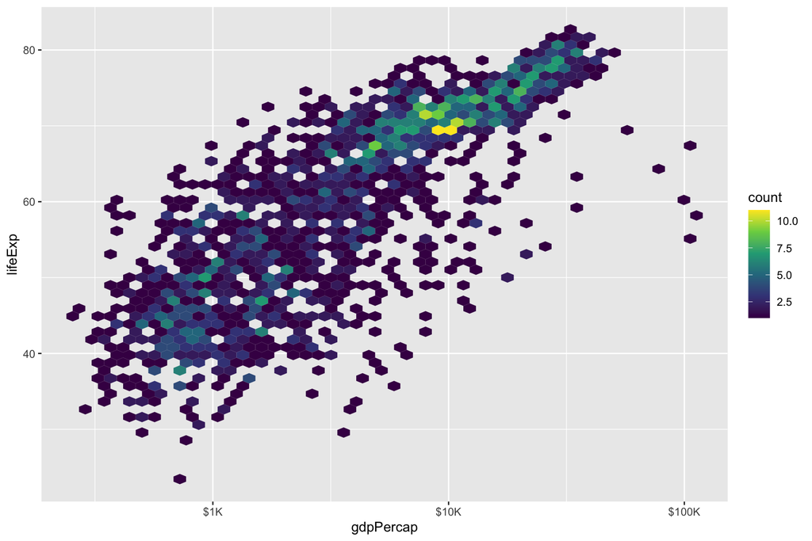

```r
g + geom_hex(bins = 50) +
    scale_x_log10(labels = label_dollar(scale_cut = cut_short_scale())) +
    scale_fill_viridis_c()
```

6. Density estimates can be drawn in two dimensions, too. The geom_density_2d() function draws contour lines estimating the joint distribution of two variables. Try it with the midwest data, for example, plotting percent below the poverty line (percbelowpoverty) against percent college-educated (percollege). Try it with and without a geom_point() layer.

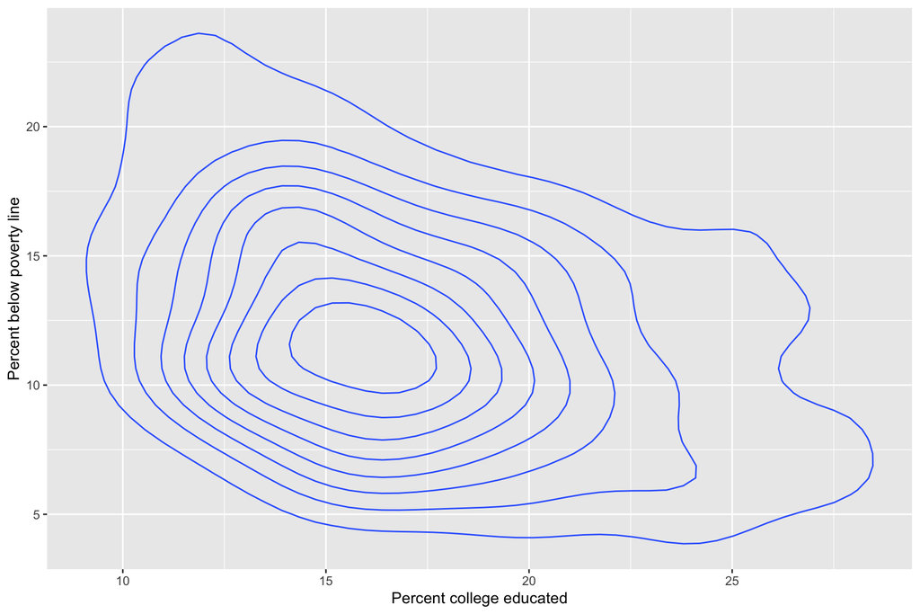

```r
d <- ggplot(midwest, aes(x = percollege, y = percbelowpoverty)) +
  labs(x = "Percent college educated", y = "Percent below poverty line")
#without geom_point()layer
d + geom_density_2d()
```

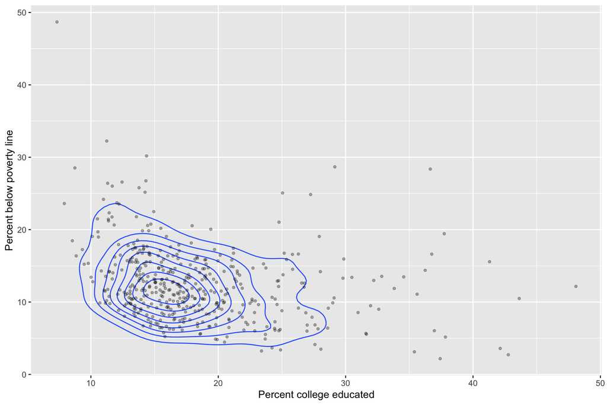

```r
#with geom_point()layer
d + geom_density_2d() + geom_point(alpha = 0.3, size = 1)
```

## Healy (2026) Chapter 5

1. Go back to your code for the presidential elections plot (Figure 5.18) and redo it so that it shows all the data points but only labels elections since 1992. You might need to look again at the elections_historic data to see what variables are available to you. You can also experiment with subsetting by political party, or changing the colors of the points to reflect the winning party.

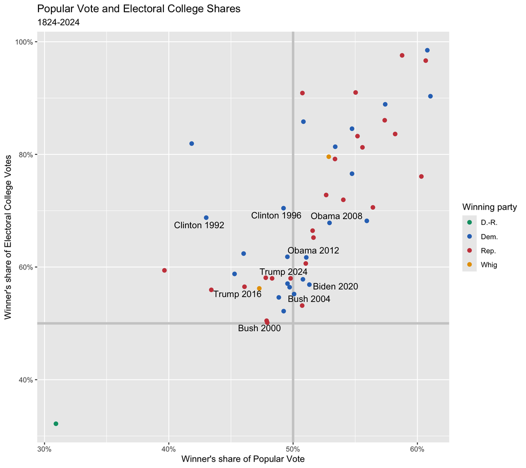

```r
#change colors of parties
party_colors <- c("Dem." = "#2E74C0", "Rep." = "#CB454A", "Whig" = "#E69F00",
                  "D.-R." = "#009E73")
p_title <- "Popular Vote and Electoral College Shares"
p_subtitle <- "1824-2024"
x_label <- "Winner's share of Popular Vote"
y_label <- "Winner's share of Electoral College Votes"

p <- ggplot(elections_historic, aes(x = popular_pct, y = ec_pct,
                                    label = winner_label))

p + geom_hline(yintercept = 0.5, size = 1.4, color = "gray80") +
    geom_vline(xintercept = 0.5, size = 1.4, color = "gray80") +
    geom_point(aes(color = win_party), size = 2) +
    geom_text_repel(data = subset(elections_historic, year >= 1992)) +
    scale_x_continuous(labels = scales::label_percent()) +
    scale_y_continuous(labels = scales::label_percent()) +
  scale_color_manual(values = party_colors) +
    labs(x = x_label, y = y_label, title = p_title,color = "Winning party",
        subtitle = p_subtitle)
```

2. Use geom_point() and reorder() to make a Cleveland dotplot of all presidential elections, ordered by share of the popular vote.

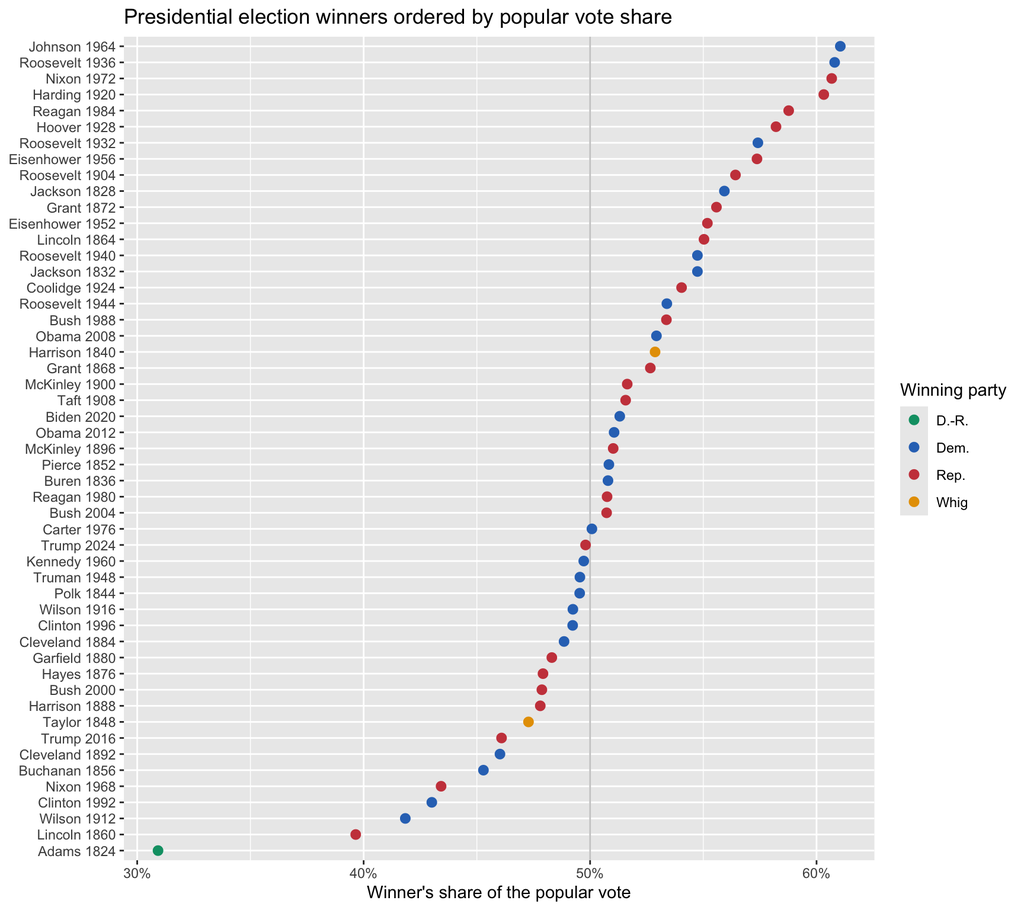

```r
ggplot(elections_historic,
       aes(x = popular_pct, y = reorder(winner_label, popular_pct), color = win_party)) +
  geom_vline(xintercept = 0.5, color = "gray80") +
  geom_point(size = 2.5) +
  scale_x_continuous(labels = percent) +
  scale_color_manual(values = party_colors) +
  labs(x = "Winner's share of the popular vote",y = NULL, color = "Winning party",
       title = "Presidential election winners ordered by popular vote share")
```

3. Try using annotate() to add a rectangle that lightly colors the entire upper left quadrant of Figure 5.18.

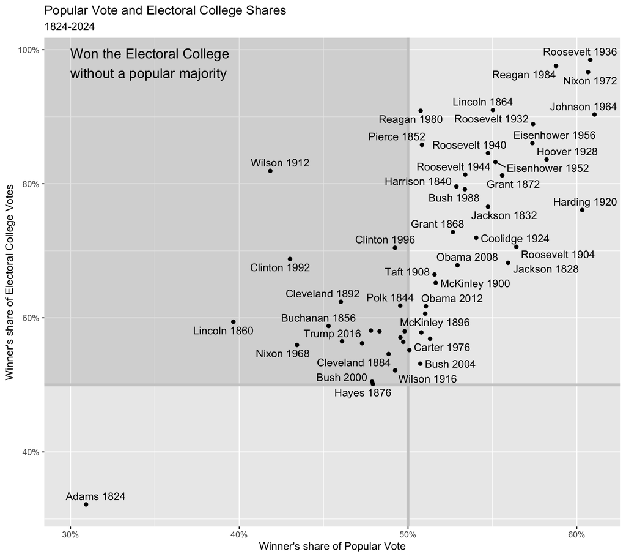

```r
p_title <- "Popular Vote and Electoral College Shares"
p_subtitle <- "1824-2024"
x_label <- "Winner's share of Popular Vote"
y_label <- "Winner's share of Electoral College Votes"

p <- ggplot(elections_historic, aes(x = popular_pct, y = ec_pct,
                                    label = winner_label))

#this quadrant means less than 50% of the popular vote but more than 50% of the Electoral College
p + annotate("rect", xmin = -Inf, xmax = 0.5, ymin = 0.5, ymax = Inf,
           fill = "gray50", alpha = 0.2) +
    annotate("text", x = 0.30, y = 0.98, hjust = 0, size = 5,
             label = "Won the Electoral College\nwithout a popular majority") +
    geom_hline(yintercept = 0.5, size = 1.4, color = "gray80") +
    geom_vline(xintercept = 0.5, size = 1.4, color = "gray80") +
    geom_point() +
    geom_text_repel() +
    scale_x_continuous(labels = scales::label_percent()) +
    scale_y_continuous(labels = scales::label_percent()) +
    labs(x = x_label, y = y_label, title = p_title,
        subtitle = p_subtitle)
```

4. The main action verbs in dplyr are group_by(), filter(), select(), summarize(), and mutate(). Practice with them by revisiting the gapminder data to see if you can reproduce a pair of graphs from Chapter 1, shown here again in Figure 5.29. You will need to filter some rows, group the data by continent, and calculate the mean life expectancy by continent before beginning the plotting process.

```r
by_continent <- gapminder |>
  filter(year == 2007) |>
  group_by(continent) |>
  summarize(N = n(),
            mean_le = mean(lifeExp)) |>
  mutate(mean_le)

by_continent
```

```
## # A tibble: 5 × 3
##   continent     N mean_le
##   <fct>     <int>   <dbl>
## 1 Africa       52    54.8
## 2 Americas     25    73.6
## 3 Asia         33    70.7
## 4 Europe       30    77.6
## 5 Oceania       2    80.7
```

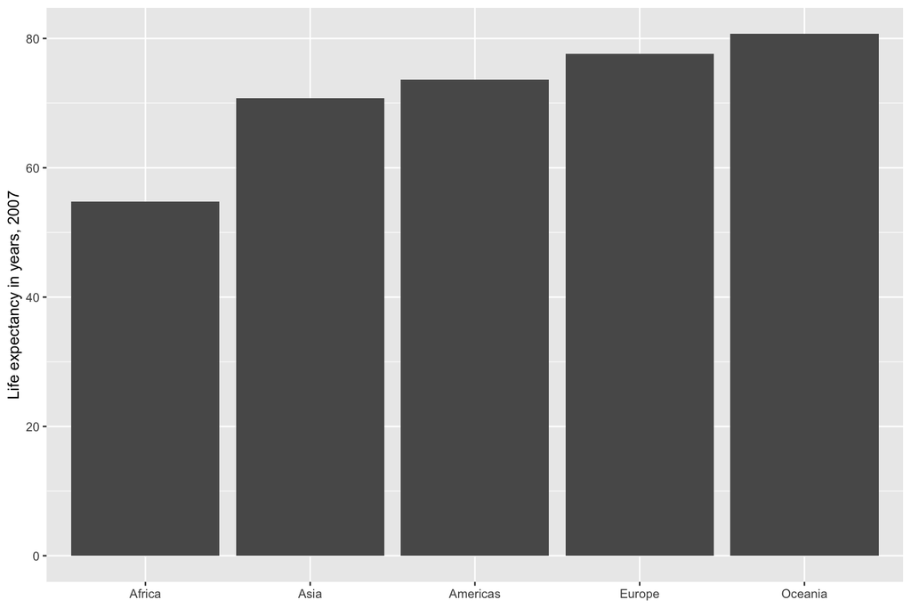

```r
p1 <- ggplot(by_continent, aes(x = reorder(continent, mean_le), y = mean_le)) +
  geom_col() +
  labs(x = NULL, y = "Life expectancy in years, 2007")

p2 <- ggplot(by_continent, aes(x = mean_le, y = reorder(continent, mean_le))) +
  geom_point(size = 5) +
  labs(x = "Life expectancy in years, 2007,", y = NULL)
p1
```

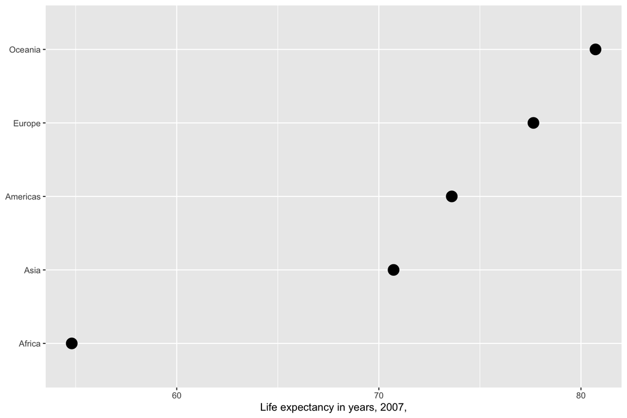

```r
p2
```

5. Try creating some grouped objects from the GSS data, calculating frequencies as you learned in this chapter, and then check to see if the totals are what you expect. For example, start by grouping degree by race, like this:

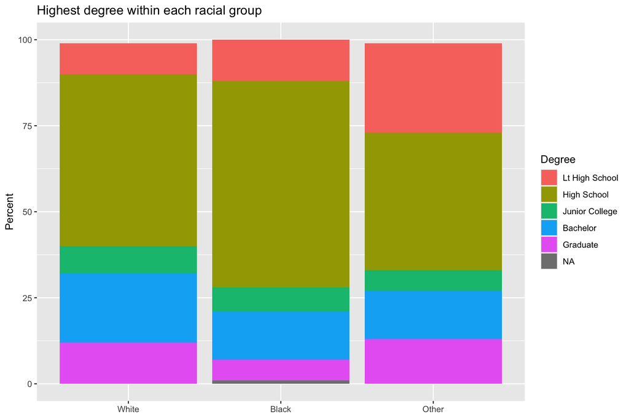

```r
rel_by_race <- gss_sm |>
  group_by(race, degree) |>
  summarize(n = n()) |>
  mutate(pct = round(n / sum(n) * 100, 0))

rel_by_race |>
  ggplot(aes(x = race, y = pct, fill = degree)) +
  geom_col() +
  labs(x = NULL, y = "Percent", fill = "Degree",
       title = "Highest degree within each racial group")
```

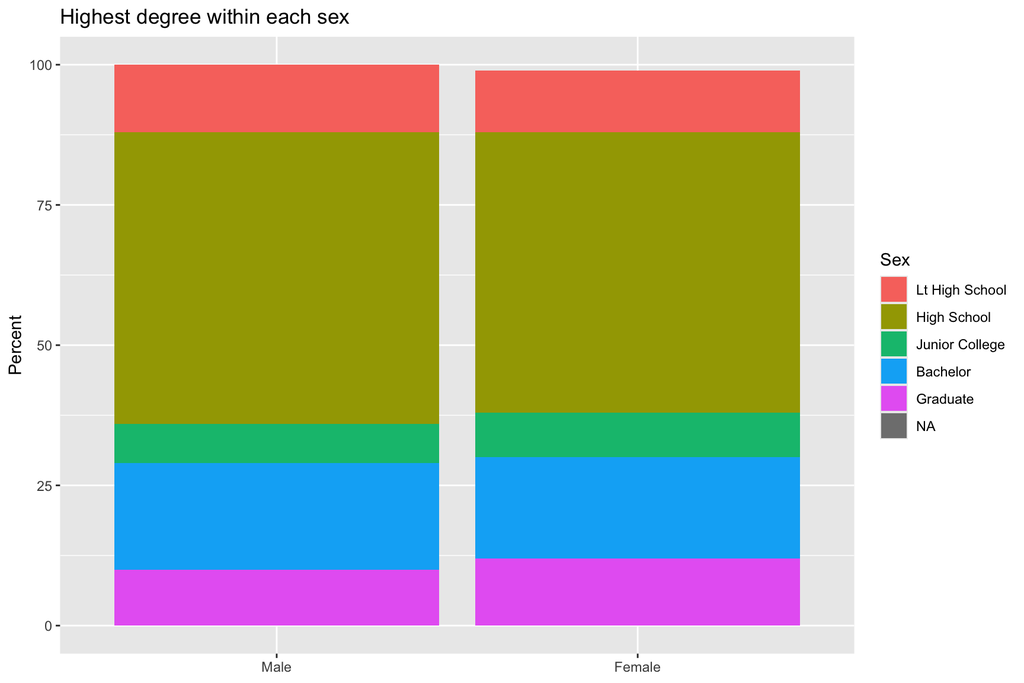

```r
#grouping by sex
rel_by_sex <-gss_sm |>
  group_by(sex, degree) |>
  summarize(n = n()) |>
  mutate(pct = round(n / sum(n) * 100, 0))

rel_by_sex|>
  ggplot(aes(x = sex, y = pct, fill = degree)) +
  geom_col() +
  labs(x = NULL, y = "Percent", fill = "Sex",
       title = "Highest degree within each sex")
```

6. Try summary calculations with functions other than sum. Can you calculate the mean and median number of children by degree? (Hint: the childs variable in gss_sm has children as a numeric value.)

```r
#Since childs is numeric, so mean() and median() work directly inside summarize()
kids <- gss_sm |>
  group_by(degree) |>
  summarize(n = n(),
            mean_kids = mean(childs, na.rm = TRUE),
            median_kids = median(childs, na.rm = TRUE),
            sd_kids = sd(childs, na.rm = TRUE))
kids
```

```
## # A tibble: 6 × 5
##   degree             n mean_kids median_kids sd_kids
##   <fct>          <int>     <dbl>       <dbl>   <dbl>
## 1 Lt High School   328      2.81           3    1.98
## 2 High School     1461      1.86           2    1.65
## 3 Junior College   216      1.77           2    1.63
## 4 Bachelor         536      1.45           1    1.44
## 5 Graduate         318      1.52           2    1.38
## 6 <NA>               8      3.6            4    1.67
```

7. Experiment with the gapminder data to practice some of the new geoms we have learned. Try examining population or life expectancy over time using a series of boxplots. (Hint: you may need to use the group aesthetic in the aes() call.) Can you facet this boxplot by continent? Is anything different if you create a tibble from gapminder that explicitly groups the data by year and continent first, and then create your plots with that?

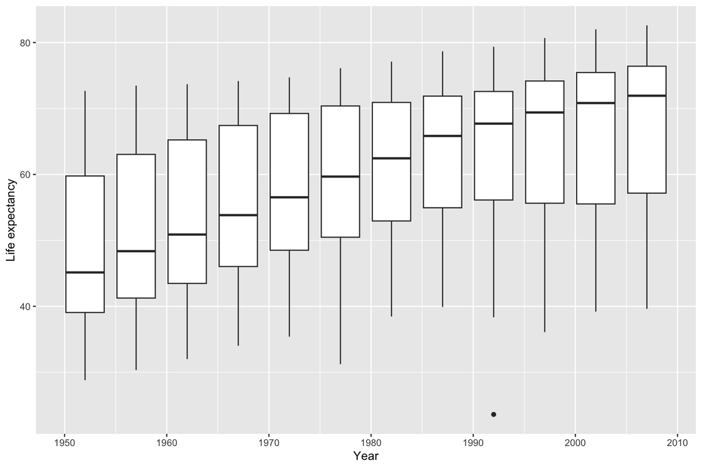

```r
ggplot(gapminder, aes(x = year, y = lifeExp, group = year)) +
  geom_boxplot() +
  labs(x = "Year", y = "Life expectancy")
```

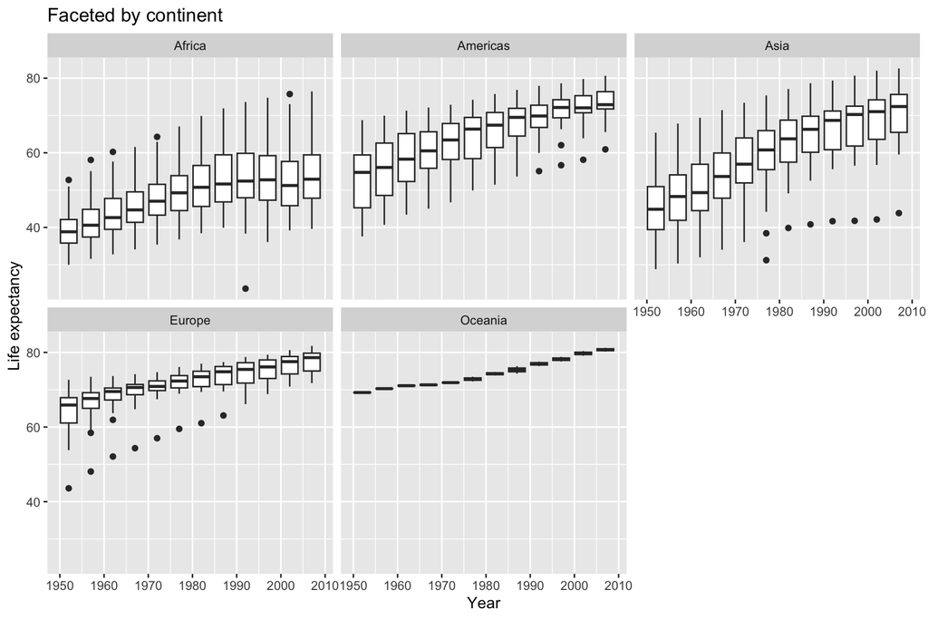

```r
#group_by(year, continent) doesn't make any difference when creating the plot
ggplot(gapminder, aes(x = year, y = lifeExp, group = year)) +
  geom_boxplot() +
  facet_wrap(~ continent) +
  labs(x = "Year", y = "Life expectancy", title = "Faceted by continent")
```

8. Read the help page for geom_boxplot() and take a look at the notch and varwidth options. Try them out to see how they change the look of the plot.

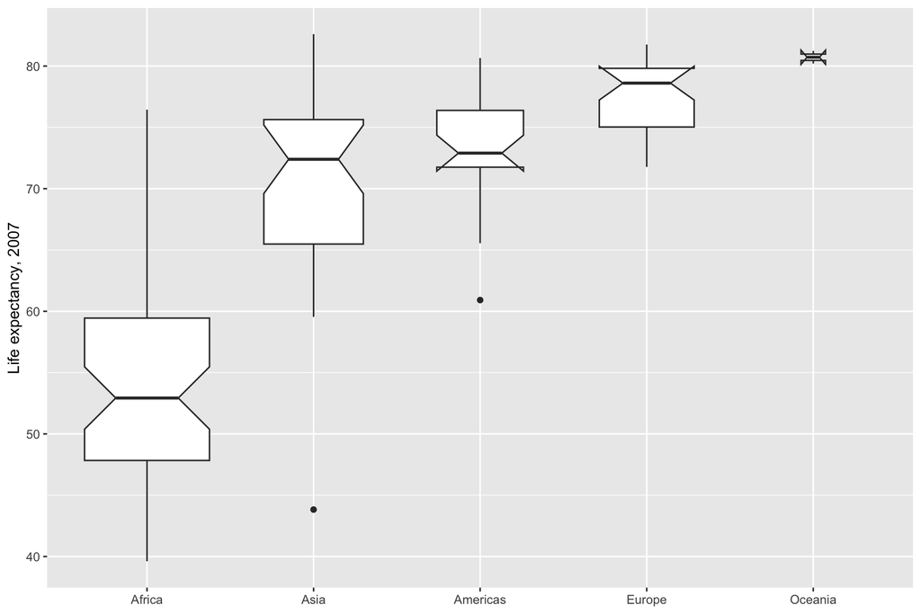

```r
#`notch = TRUE` cuts a notch around each median. If two boxes' notches don't overlap, that is rough evidence that their medians differ.
#`varwidth = TRUE` makes each box's width proportional to the square root of its number of observations, so groups based on more data look bigger.

gapminder |>
  filter(year == 2007) |>
  ggplot(aes(x = reorder(continent, lifeExp), y = lifeExp)) +
  geom_boxplot(notch = TRUE, varwidth = TRUE) +
  labs(x = NULL, y = "Life expectancy, 2007")
```

9. As an alternative to geom_boxplot(), try geom_violin() for a similar plot but with a mirrored density distribution instead of a box and whiskers.

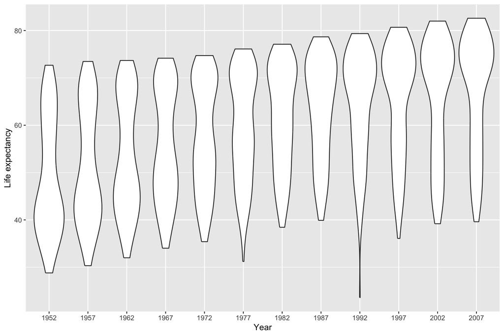

```r
ggplot(gapminder, aes(x = factor(year), y = lifeExp)) +
  geom_violin() +
  labs(x = "Year", y = "Life expectancy")
```

10. geom_pointrange() is one of a family of related geoms that produce different kinds of error bars and ranges, depending on your specific needs. They include geom_linerange(), geom_crossbar(), and geom_errorbar(). Try them out using gapminder or organdata to see how they differ.

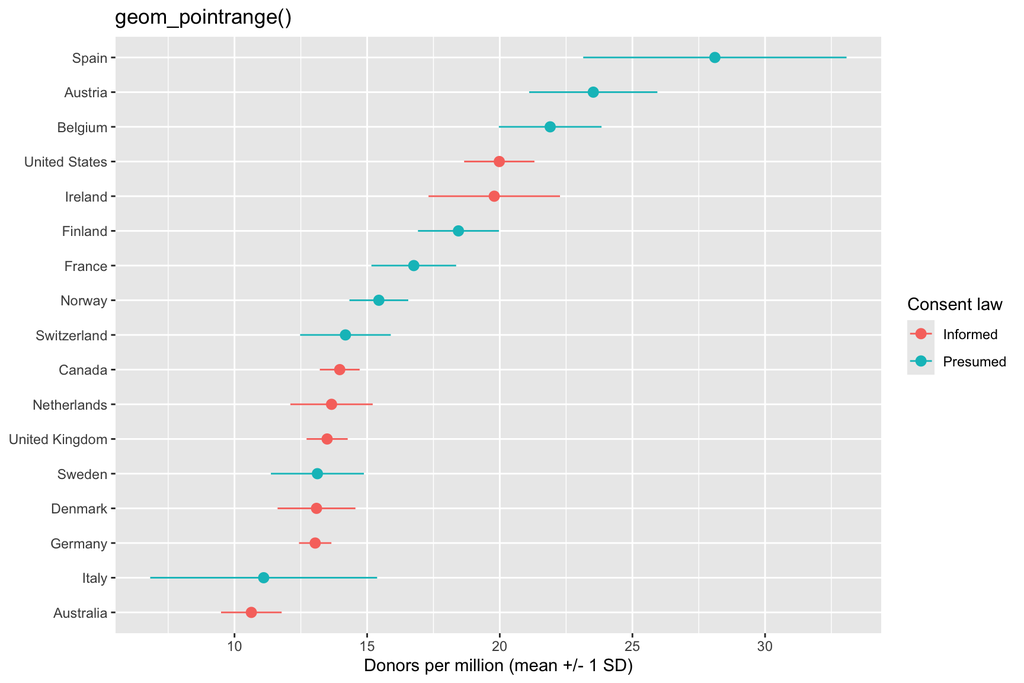

```r
by_country <- organdata |>
  group_by(consent_law, country) |>
  summarize(donors_mean = mean(donors, na.rm = TRUE),
            donors_sd = sd(donors, na.rm = TRUE),
            .groups = "drop") |>
  mutate(lo = donors_mean - donors_sd, hi = donors_mean + donors_sd)

base <- ggplot(by_country,
               aes(x = donors_mean, y = reorder(country, donors_mean),
                   xmin = lo, xmax = hi, color = consent_law)) +
  labs(x = "Donors per million (mean +/- 1 SD)", y = NULL, color = "Consent law")

r1 <- base + geom_pointrange() + labs(title = "geom_pointrange()")
r2 <- base + geom_linerange() + labs(title = "geom_linerange()")
r3 <- base + geom_crossbar() + labs(title = "geom_crossbar()")
r4 <- base + geom_errorbar() + geom_point() + labs(title = "geom_errorbar() + geom_point()")
r1
```

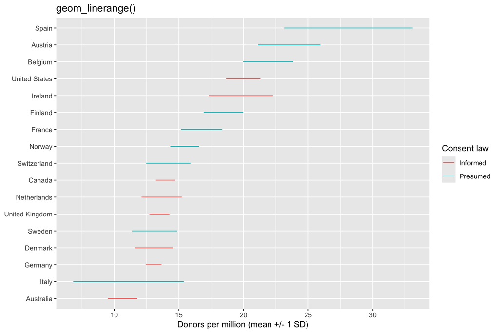

```r
r2
```

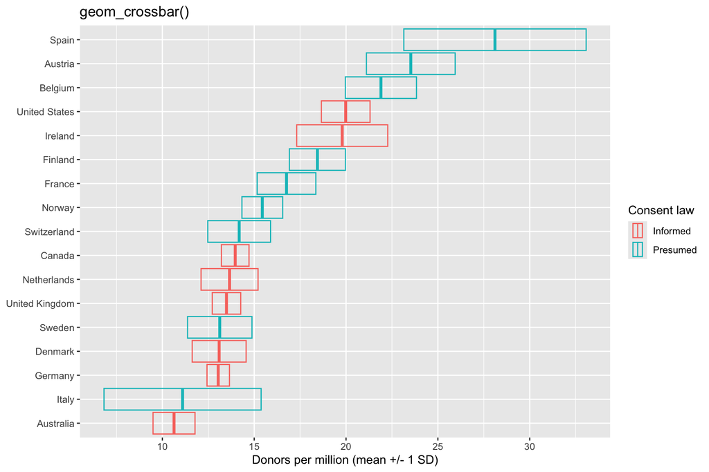

```r
r3
```

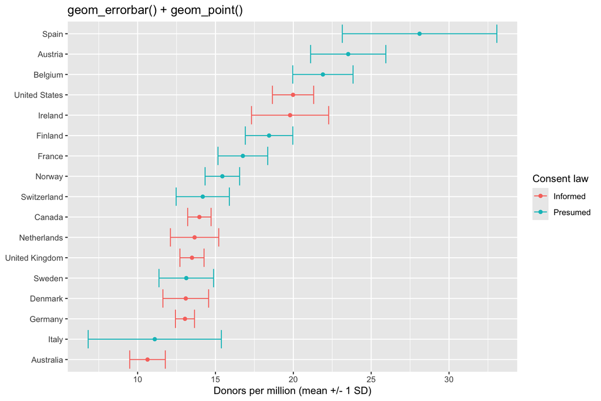

```r
r4
```

## Bulut & Dejardins (2019) chapter 5

Get prepared:

```r
library("ggplot2")
library("GGally")
library("ggExtra")
library("ggalluvial")
library("plotly")
# Load already installed packages
library(data.table)
```

```r
#load dataset
pisa <- fread("pisa2015.csv", na.strings = "")
```

```r
country <- c("United States", "Canada", "Mexico", "B-S-J-G (China)", "Japan",
             "Korea", "Germany", "Italy", "France", "Brazil", "Colombia", "Uruguay",
             "Australia", "New Zealand", "Jordan", "Israel", "Lebanon")
bin.to.num <- function(x){
  if (is.na(x)) NA
  else if (x == "Yes") 1L
  else if (x == "No") 0L
}
pisa[, `:=`
     (female = ifelse(ST004D01T == "Female", 1, 0),
       sex = ST004D01T,desk = sapply(ST011Q01TA, bin.to.num),
       own.room = sapply(ST011Q02TA, bin.to.num),
       quiet.study = sapply(ST011Q03TA, bin.to.num),
       computer = sapply(ST011Q04TA, bin.to.num),
       software = sapply(ST011Q05TA, bin.to.num),
       internet = sapply(ST011Q06TA, bin.to.num),
       lit = sapply(ST011Q07TA, bin.to.num),
       poetry = sapply(ST011Q08TA, bin.to.num),
       art = sapply(ST011Q09TA, bin.to.num),
       book.sch = sapply(ST011Q10TA, bin.to.num),
       tech.book = sapply(ST011Q11TA, bin.to.num),
       dict = sapply(ST011Q12TA, bin.to.num),
       art.book = sapply(ST011Q16NA, bin.to.num))]
pisa[, `:=`
     (math = rowMeans(pisa[, c(paste0("PV", 1:10, "MATH"))], na.rm = TRUE),
       reading = rowMeans(pisa[, c(paste0("PV", 1:10, "READ"))], na.rm = TRUE),
       science = rowMeans(pisa[, c(paste0("PV", 1:10, "SCIE"))], na.rm = TRUE))]
dat <- pisa[CNT %in% country,
            .(CNT, OECD, CNTSTUID, W_FSTUWT, sex, female,
              ST001D01T, computer, software, internet,
              ST011Q05TA, ST071Q02NA, ST071Q01NA, ST123Q02NA,
              ST082Q01NA, ST119Q01NA, ST119Q05NA, ANXTEST,
              COOPERATE, BELONG,  EMOSUPS, HOMESCH, ENTUSE,
              ICTHOME, ICTSCH, WEALTH, PARED, TMINS, ESCS,
              TEACHSUP, TDTEACH, IBTEACH, SCIEEFF,
              math, reading, science)
            ]
dat <- dat[, `:=` (
  # New grade variable
  grade = (as.numeric(sapply(ST001D01T, function(x) {
  if(x=="Grade 7") "7"
  else if (x=="Grade 8") "8"
  else if (x=="Grade 9") "9"
  else if (x=="Grade 10") "10"
  else if (x=="Grade 11") "11"
  else if (x=="Grade 12") "12"
  else if (x=="Grade 13") NA_character_
  else if (x=="Ungraded") NA_character_}))),
  # Total learning time as hours
  learning = round(TMINS/60, 0),
  # Regions for selected countries
  Region = (sapply(CNT, function(x) {
  if(x %in% c("Canada", "United States", "Mexico")) "N. America"
    else if (x %in% c("Colombia", "Brazil", "Uruguay")) "S. America"
    else if (x %in% c("Japan", "B-S-J-G (China)", "Korea")) "Asia"
    else if (x %in% c("Germany", "Italy", "France")) "Europe"
    else if (x %in% c("Australia", "New Zealand")) "Australia"
    else if (x %in% c("Israel", "Jordan", "Lebanon")) "Middle-East"
    }))
  )]
```

# 5.2.1

1. Create a plot of math scores over countries with different colors based on region.

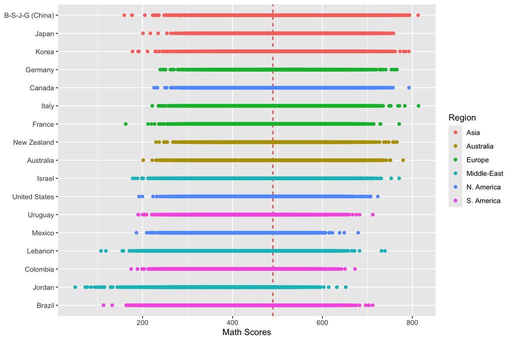

```
##    user  system elapsed
##   2.072   0.015   2.094
```

```r
base <- ggplot(dat, aes(x = reorder(CNT, math), y = math)) +
  geom_hline(yintercept = 490, linetype = "dashed", color = "red") +
  labs(x = NULL, y = "Math Scores") +
  coord_flip()
system.time(print(base + geom_point(aes(color = Region))))
```

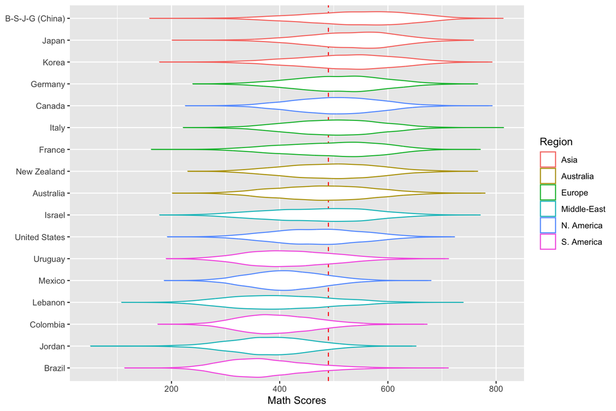

```
##    user  system elapsed
##   0.346   0.027   0.377
```

```r
system.time(print(base + geom_violin(aes(color = Region))))
```

The point plot is slower, probably because ggplot has to draw all ~158,000 students one by one. I tried to use alpha to show the points density, but it doesn’t work well. For large data like this, the violin is the better choice.

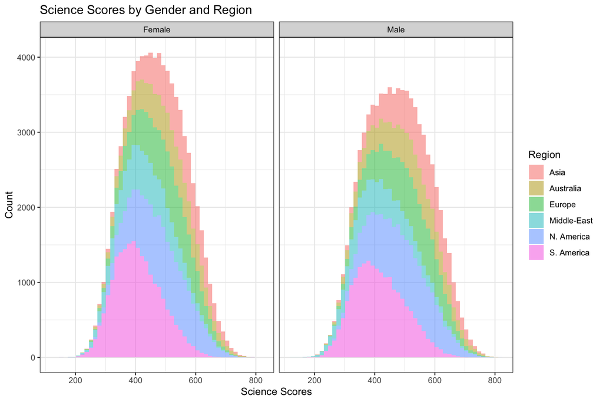

```r
ggplot(data = dat,
       mapping = aes(x = science, fill = Region)) +
  geom_histogram(alpha = 0.5, bins = 50) +
  labs(x = "Science Scores", y = "Count",
       title = "Science Scores by Gender and Region") +
  facet_grid(. ~ sex) +
  theme_bw()
```

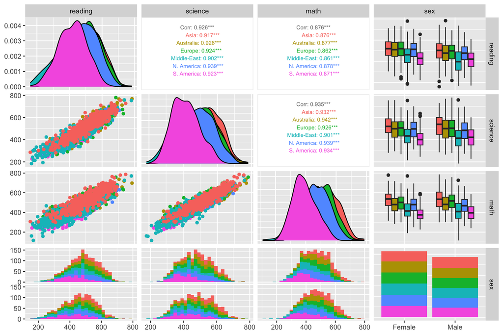

```r
# Random sample of 500 students from each region
dat_small <- dat[,.SD[sample(.N, min(500,.N))], by = Region]

ggpairs(data = dat_small,
        mapping = aes(color = Region),
        columns = c("reading", "science", "math", "sex"),
        upper = list(continuous = wrap("cor", size = 2.5))
        )
```

Q: What can we say about the regions based on the plots above?

A: Asia shows the highest scores in all three subjects. South America shows a lower score than other regions

Q: Do you see any major gender differences for reading, science, or math?

A: Not really. The male and female boxplots overlap almost completely in all three subjects. The only consistent difference is in reading, girls score a little higher.

Q: What is the relationship among reading, science, or math?

A: Strongly positive. The scatterplots are upward-sloping clouds, and the correlations in the upper panels are high. Math and science are usually the most strongly related pair.

# 5.3.1

Create a scatterplot of socio-economic status (ESCS) and math scores (math) across regions (region) and gender (sex). Use geom_smooth(method = “lm”) to draw linear regression lines (instead of loess smoothing). Do you think that the relationship between ESCS and math changes across gender and regions?

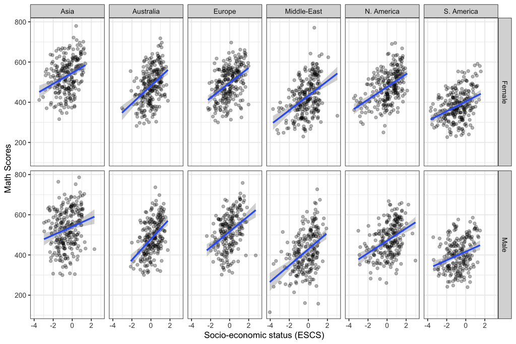

```r
ggplot(dat_small, aes(x = ESCS, y = math)) +
  geom_point(alpha = 0.3) +
  geom_smooth(method = "lm") +
  facet_grid(sex ~ Region) +
  labs(x = "Socio-economic status (ESCS)", y = "Math Scores") +
  theme_bw()
```

Students with higher socio-economic status tend to have higher math scores. So the relationship differs more by region than by gender.

# 5.6.1

Create an alluvial plot for the survey item (ST119Q01NA) of whether students want top grades in most or all courses by region (Region) and gender (sex). Below we create the summary dataset (dat_alluvial2) for this plot. Use this dataset to draw the alluvial plot plot. How should we interpret the plot (e.g., for each region)?

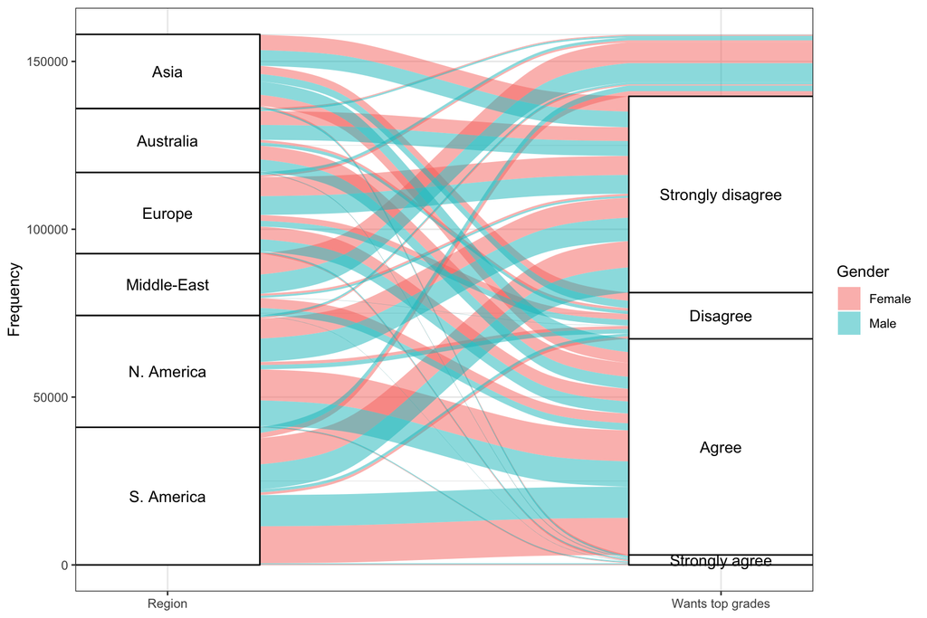

```r
dat_alluvial2 <- dat[,
                     .(Freq = .N),
                     by = c("Region", "sex", "ST119Q01NA")
                     ][,
                       ST119Q01NA := as.factor(ifelse(ST119Q01NA == "", "Missing", ST119Q01NA))]

levels(dat_alluvial2$ST119Q01NA) <- c("Strongly disagree", "Disagree", "Agree",
                                      "Strongly agree", "Missing")
ggplot(dat_alluvial2, aes(axis1 = Region, axis2 = ST119Q01NA, y = Freq)) +
  geom_alluvium(aes(fill = sex)) +
  geom_stratum() +
  geom_text(stat = "stratum", aes(label = after_stat(stratum))) +
  scale_x_discrete(limits = c("Region", "Wants top grades"), expand = c(.1, .05)) +
  labs(y = "Frequency", fill = "Gender") +
  theme_bw()
```

# 5.7.1

Replicate the science-by-region histogram below as a density plot and useplotly to make it interactive. You will need to replace geom_histogram(alpha = 0.5, bins = 50) with geom_density(alpha = 0.5). Repeat the same process by changing alpha = 0.5 to alpha = 0.8. Which version is better for examining the science score distribution?

```r
p<- ggplot(data = dat,
       mapping = aes(x = science, fill = Region)) +
  geom_density(alpha = 0.5) +
  labs(x = "Science Scores", y = "Count",
       title = "Science Scores by Gender and Region") +
  facet_grid(. ~ sex) +
  theme_bw()
ggplotly(p)
```

[interactive chart not shown]

alpha = 0.5 is better than alpha = 0.8 for examining the science score distribution, because it is more transparant and the curves in the back can be more readable.

# 5.9

Create at least two visualizations (either static or interactive) using some of the variables shown below

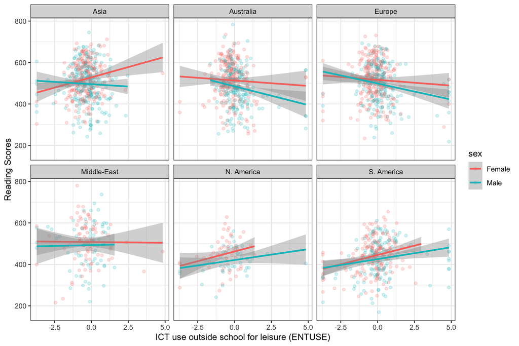

```r
#Plot 1: ENTUSE ~ reading scores by sex and region
ggplot(dat_small, aes(x = ENTUSE, y = reading, color = sex)) +
  geom_point(alpha = 0.2) +
  geom_smooth(method = "lm") +
  facet_wrap(~ Region) +
  labs(x = "ICT use outside school for leisure (ENTUSE)", y = "Reading Scores") +
  theme_bw()
```

```r
#Plot 2: ICTHOME ~ mean reading scores by region
ict_reading <- dat[!is.na(ICTHOME),
                   .(reading = mean(reading, na.rm = TRUE), N = .N),
                   by = .(Region, ICTHOME)]

lab <-ggplot(ict_reading, aes(x = ICTHOME, y = reading, color = Region)) +
  geom_line() +
  geom_point(aes(size = N)) +
  labs(x = "ICT resources available at home (ICTHOME)", y = "Mean Reading Score",
       size = "Students") +
  theme_bw()
ggplotly(lab)
```

[interactive chart not shown]